# Notes on Ch 10: EDA

N_Lim

2025-07-03

- EDA is an iterative ccycle where you:
1. Generate questions about your data.
2. Search for answers by visualizing, transforming, and modelling your data.
3. Use what you learned to refine your questions and/or generate new questions.
- EDA is not a formal process.
- It has no strict set of rules.

### Prerequisites

```r
library(tidyverse)
```

Goal during EDA: - Develop an understanding of data. - Use questions as tools to guide your investigation.

Questions that will always be useful for discovering or uncovering something in your data: 1. What type of variation occurs within my variables? 2. What type of covariation occurs between my variables?

```r
glimpse(diamonds)
```

```
## Rows: 53,940
## Columns: 10
## $ carat   <dbl> 0.23, 0.21, 0.23, 0.29, 0.31, 0.24, 0.24, 0.26, 0.22, 0.23, 0.…
## $ cut     <ord> Ideal, Premium, Good, Premium, Good, Very Good, Very Good, Ver…
## $ color   <ord> E, E, E, I, J, J, I, H, E, H, J, J, F, J, E, E, I, J, J, J, I,…
## $ clarity <ord> SI2, SI1, VS1, VS2, SI2, VVS2, VVS1, SI1, VS2, VS1, SI1, VS1, …
## $ depth   <dbl> 61.5, 59.8, 56.9, 62.4, 63.3, 62.8, 62.3, 61.9, 65.1, 59.4, 64…
## $ table   <dbl> 55, 61, 65, 58, 58, 57, 57, 55, 61, 61, 55, 56, 61, 54, 62, 58…
## $ price   <int> 326, 326, 327, 334, 335, 336, 336, 337, 337, 338, 339, 340, 34…
## $ x       <dbl> 3.95, 3.89, 4.05, 4.20, 4.34, 3.94, 3.95, 4.07, 3.87, 4.00, 4.…
## $ y       <dbl> 3.98, 3.84, 4.07, 4.23, 4.35, 3.96, 3.98, 4.11, 3.78, 4.05, 4.…
## $ z       <dbl> 2.43, 2.31, 2.31, 2.63, 2.75, 2.48, 2.47, 2.53, 2.49, 2.39, 2.…
```

## Variation

- Tendency of the values of a variable to change from measurement to measurement.

Example: Visualizing the distribution of weights (`carat`) of about 54 000 diamonds from the `diamonds` dataset:

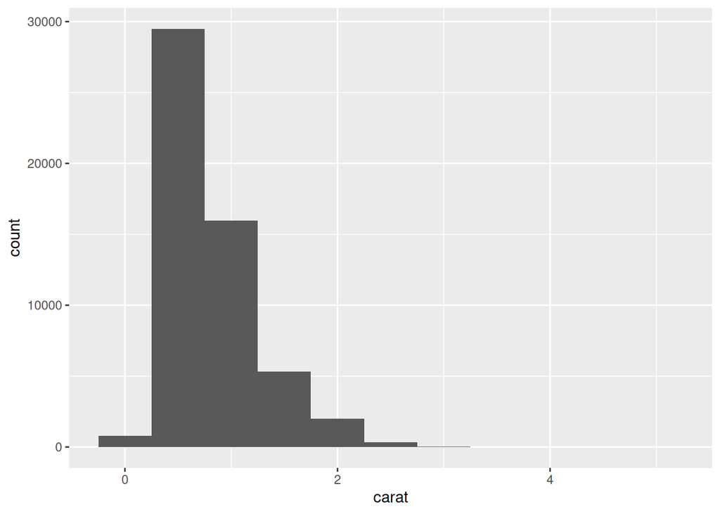

```r
ggplot(diamonds, aes(x = carat)) +
  geom_histogram(binwidth = 0.5)
```

- The tall bars show the common values of a variable; the shorter bars show less-common values.

Ask: - Which values are the most common? Why? - Which values are rare? Why? Does that match your expectations? - Can you see any unusual patterns? If so, what might explain them?

Looking at the distribution of `carat` for smaller diamonds:

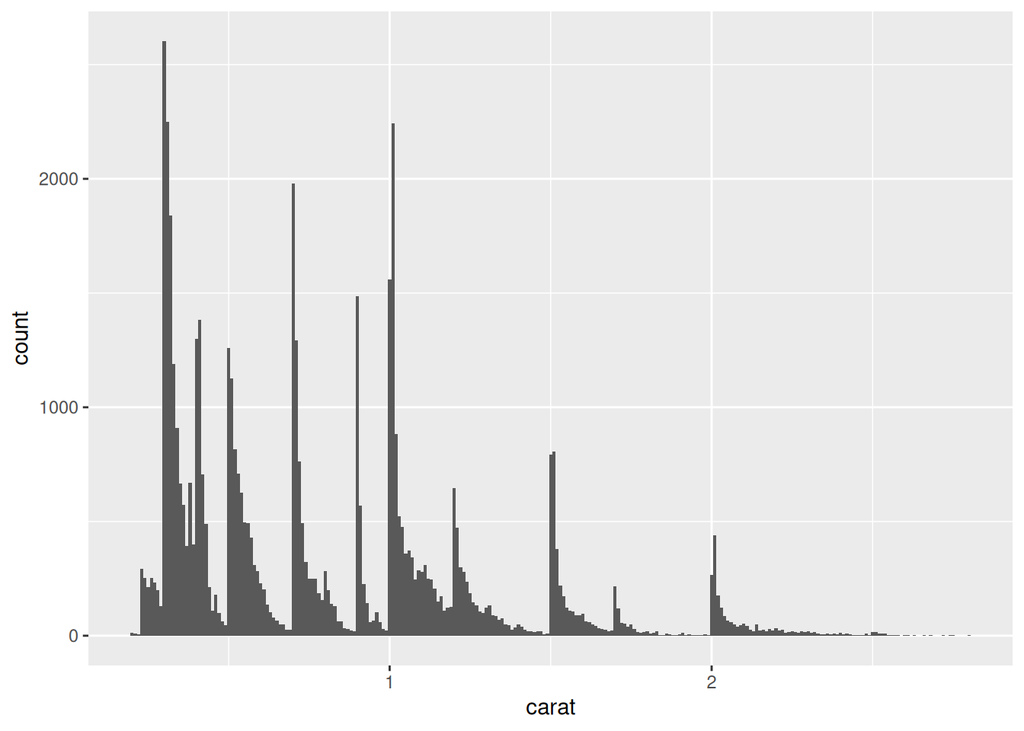

```r
smaller <-
  diamonds |> filter(carat < 3)

ggplot(smaller, aes(x = carat)) +
  geom_histogram(binwidth = 0.01)
```

- It seems like there are more diamonds at whole carats and some fractions of carats. Why?
- Why are there more diamonds slightly to the right of each peak than there are to the left of each peak?

Visualizations can also reveal clusters and/or subgroups in the data. To understand the subgroups in `diamonds`, we can ask: - How are the observations within each subgroup similar to each other?  
- How are the observations in separate clusters different from each other?  
- How can you explain or describe the clusters?  
- Why might the appearance of clusters be misleading?

## Unusual values

Outliers: Observations that are unusual, data points that don’t seem to fit the pattern.

Looking for outliers in `diamonds`:

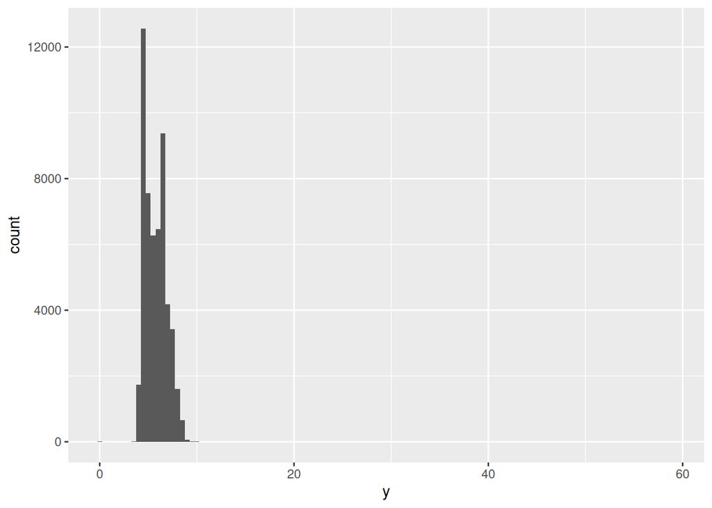

```r
ggplot(diamonds, aes(x = y)) +
  geom_histogram(binwidth = 0.5)
```

It is hard to see if there are very short bars in this histogram. We need to zoom in closer:

Zooming in using `coor_cartesian()`:

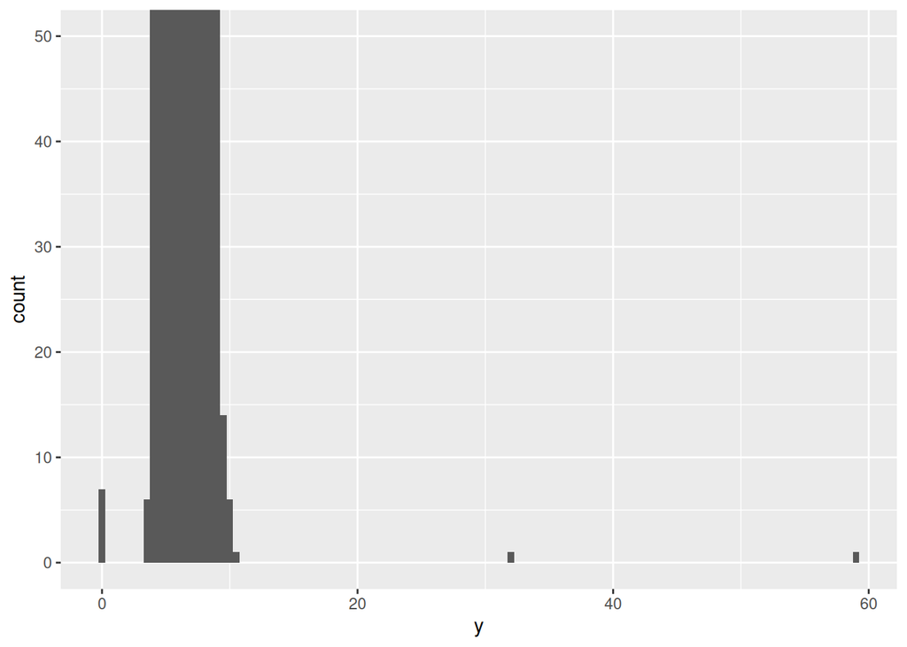

```r
ggplot(diamonds, aes(x = y)) +
  geom_histogram(binwidth = 0.5) +
  coord_cartesian(ylim = c(0, 50))
```

Aha!

Note: `coord_catesian()` has an `xlim()` argument too. The regular `xlim()` and `ylim()` functions in `ggplot2` work slightly differently – they throw away the data outside the limits.

Extracting the unusual values:

```r
unusual <- diamonds |>
  filter(y < 3 | y > 20) |>
  select(price, x, y, z) |>
  arrange(y)

unusual
```

```
## # A tibble: 9 × 4
##   price     x     y     z
##   <int> <dbl> <dbl> <dbl>
## 1  5139  0      0    0
## 2  6381  0      0    0
## 3 12800  0      0    0
## 4 15686  0      0    0
## 5 18034  0      0    0
## 6  2130  0      0    0
## 7  2130  0      0    0
## 8  2075  5.15  31.8  5.12
## 9 12210  8.09  58.9  8.06
```

- The zero-values seem to suggest that these are missing data that are coded as 0’s instead of `NA`s. We might chose to re-code these values as `NA`.
- The values higher than higher than 20 seem to be incorrect as well – the prices are too “cheap” for their size!

### Exercises:

E1. Explore the distribution of each of the `x`, `y`, and `z` variables in `diamonds`. What do you learn? Thin about a diamond and how you might decide which dimension is the length, width, and depth.

Ans.

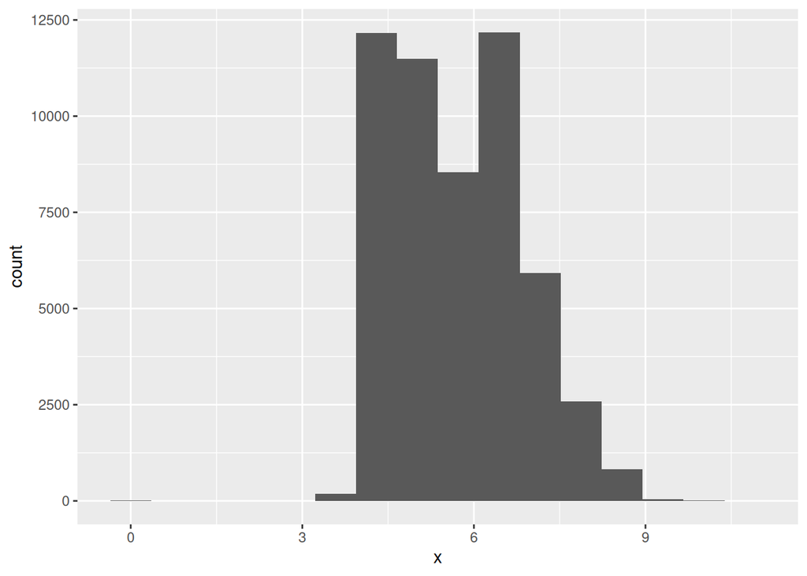

```r
# using Sturge's rule to get optmal no. of bins
N = 53490
K = as.integer(1 + 3.322 * log10(N))

# distribution of x
ggplot(diamonds, aes(x = x)) +
  geom_histogram(bins = K)
```

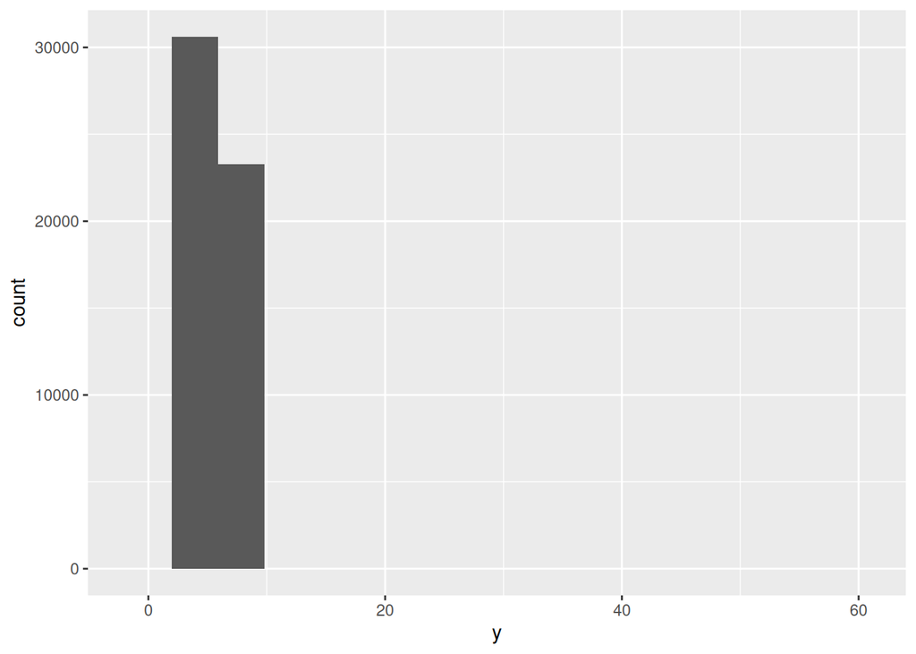

```r
# distribution of y
ggplot(diamonds, aes(x = y)) +
  geom_histogram(bins = K)
```

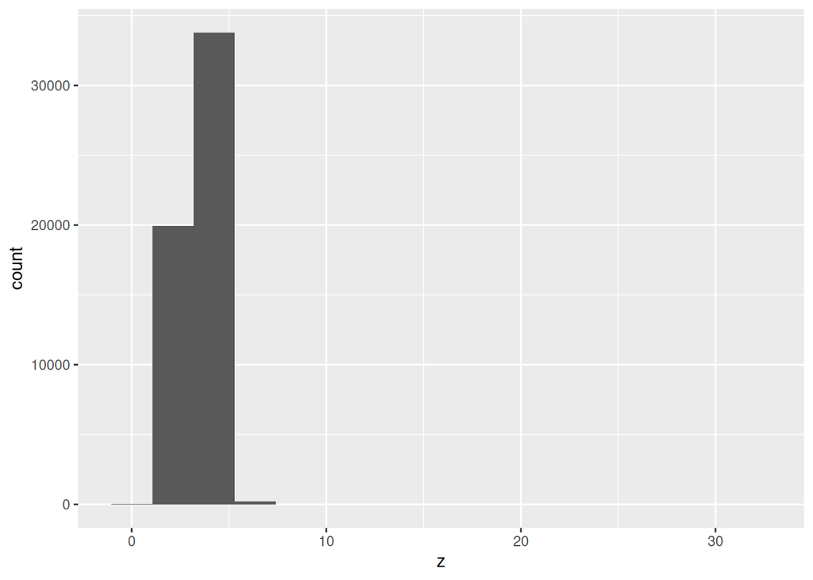

```r
ggplot(diamonds, aes(x = z)) +
  geom_histogram(bins = K)
```

E2. Explore the distribution of `price`. Do you discover anything unusual or surprising? (hint: Carefully think about the `binwidth`) and make sure you try a wide range of values.